# Latihan 3 New Delhi Air Quality

Data yang digunakan adalah data **kualitas udara Kota New Delhi** yang terdiri atas 72 pengamatan per jam (21 Oktober 2022 pukul 18.00 sampai 24 Oktober 2022). Peubah yang digunakan:

- **Peubah respon (Y)**: `AQI` (*Air Quality Index*)
- **Peubah penjelas (X)**: `o3` (konsentrasi ozon)

Peubah `o3` dipilih sebagai peubah penjelas karena memiliki korelasi paling kuat terhadap AQI dibandingkan polutan lain (CO, NO2, PM10, PM2.5, dan SO2).

Tujuan analisis adalah menerapkan beberapa model regresi dengan peubah *lag* (Koyck, *Distributed Lag Model*, dan *Autoregressive Distributed Lag*), lalu menentukan model terbaik berdasarkan metrik akurasi.

# Library

```r
library(dLagM)
library(dynlm)
library(MLmetrics)
library(lmtest)
library(car)
```

# Impor Data

```r
data <- rio::import("C:\\Users\\HYPE R Series\\Downloads\\NewDelhi_Air_quality (1).csv")

str(data)
```

```
## 'data.frame':    72 obs. of  12 variables:
##  $ V1             : int  0 1 2 3 4 5 6 7 8 9 ...
##  $ AQI            : num  30.2 28.2 26.6 25 26 26 26 24 23 24 ...
##  $ CO             : num  199 198 199 202 205 ...
##  $ datetime       : chr  "2022-10-21:18" "2022-10-21:19" "2022-10-21:20" "2022-10-21:21" ...
##  $ no2            : num  0.0469 0.0465 0.0469 0.0482 0.0489 ...
##  $ o3             : num  55.8 54.9 54.6 55.1 55.8 ...
##  $ pm10           : num  10.5 10.7 11.2 11.1 10.4 ...
##  $ pm25           : num  5.64 4.62 3.52 2.23 1.98 ...
##  $ so2            : num  0.387 0.41 0.402 0.376 0.339 ...
##  $ timestamp_local: POSIXct, format: "2022-10-21 23:00:00" "2022-10-22 00:00:00" ...
##  $ timestamp_utc  : POSIXct, format: "2022-10-21 18:00:00" "2022-10-21 19:00:00" ...
##  $ ts             : int  1666375200 1666378800 1666382400 1666386000 1666389600 1666393200 1666396800 1666400400 1666404000 1666407600 ...
```

```r
head(data)
```

```
##   V1  AQI       CO      datetime        no2       o3      pm10     pm25
## 1  0 30.2 198.6027 2022-10-21:18 0.04685717 55.78995 10.486722 5.637410
## 2  1 28.2 197.6013 2022-10-21:19 0.04645554 54.93164 10.719325 4.618169
## 3  2 26.6 198.6027 2022-10-21:20 0.04685717 54.64554 11.155578 3.520902
## 4  3 25.0 201.9405 2022-10-21:21 0.04819594 55.07469 11.116206 2.225919
## 5  4 26.0 205.2784 2022-10-21:22 0.04886533 55.78995 10.405250 1.979471
## 6  5 26.0 208.6163 2022-10-21:23 0.05020411 56.50520  9.402518 1.792677
##         so2     timestamp_local       timestamp_utc         ts
## 1 0.3874302 2022-10-21 23:00:00 2022-10-21 18:00:00 1666375200
## 2 0.4097819 2022-10-22 00:00:00 2022-10-21 19:00:00 1666378800
## 3 0.4023313 2022-10-22 01:00:00 2022-10-21 20:00:00 1666382400
## 4 0.3762543 2022-10-22 02:00:00 2022-10-21 21:00:00 1666386000
## 5 0.3390014 2022-10-22 03:00:00 2022-10-21 22:00:00 1666389600
## 6 0.3129244 2022-10-22 04:00:00 2022-10-21 23:00:00 1666393200
```

## Pemilihan Peubah Penjelas

```r
polutan <- c("CO", "no2", "o3", "pm10", "pm25", "so2")
kor <- sapply(data[polutan], function(z) cor(data$AQI, z))
round(sort(abs(kor), decreasing = TRUE), 4)
```

```
##     o3     CO    so2    no2   pm25   pm10
## 0.9736 0.7976 0.7425 0.7377 0.3467 0.0826
```

```r
round(kor, 4)
```

```
##      CO     no2      o3    pm10    pm25     so2
##  0.7976  0.7377  0.9736  0.0826 -0.3467 -0.7425
```

Korelasi tertinggi diperoleh pada peubah `o3` ($r \approx 0{,}9736$), sehingga `o3` ditetapkan sebagai peubah penjelas $X$.

## Pembentukan Data Kerja

```r
data <- data.frame(t = 1:nrow(data), Yt = data$AQI, Xt = data$o3)
str(data)
```

```
## 'data.frame':    72 obs. of  3 variables:
##  $ t : int  1 2 3 4 5 6 7 8 9 10 ...
##  $ Yt: num  30.2 28.2 26.6 25 26 26 26 24 23 24 ...
##  $ Xt: num  55.8 54.9 54.6 55.1 55.8 ...
```

```r
summary(data[, c("Yt", "Xt")])
```

```
##        Yt              Xt
##  Min.   :19.00   Min.   :41.48
##  1st Qu.:25.00   1st Qu.:53.64
##  Median :27.00   Median :57.22
##  Mean   :26.18   Mean   :56.57
##  3rd Qu.:28.00   3rd Qu.:60.08
##  Max.   :32.00   Max.   :68.66
```

# Eksplorasi Data

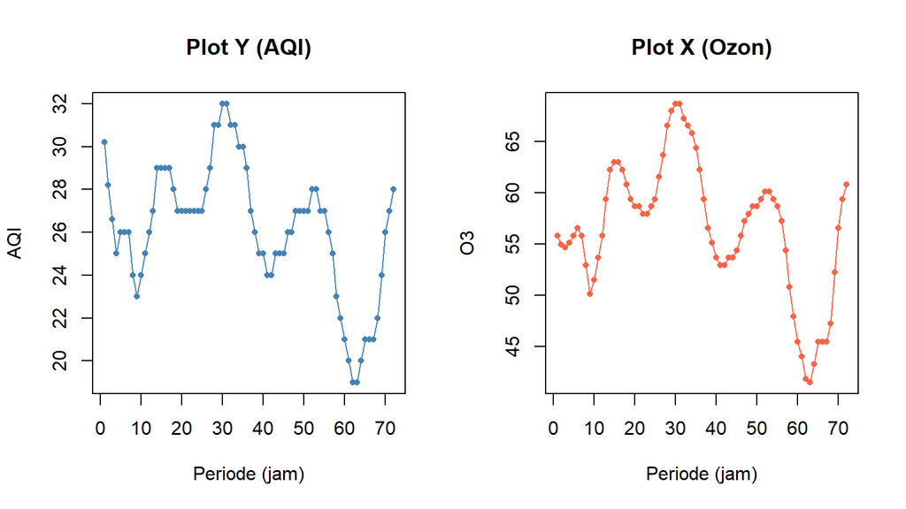

```r
par(mfrow = c(1, 2))
plot(data$t, data$Yt, type = "o", pch = 16, cex = 0.7, col = "steelblue",
     xlab = "Periode (jam)", ylab = "AQI", main = "Plot Y (AQI)")
plot(data$t, data$Xt, type = "o", pch = 16, cex = 0.7, col = "tomato",
     xlab = "Periode (jam)", ylab = "O3", main = "Plot X (Ozon)")
```

```r
par(mfrow = c(1, 1))
```

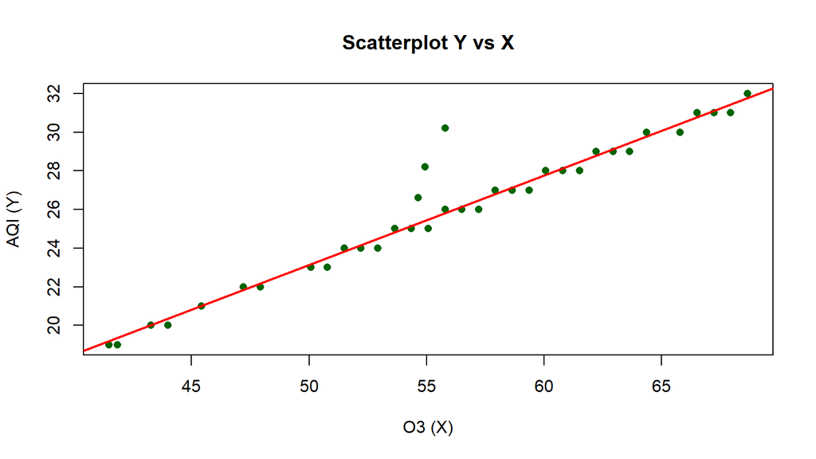

```r
plot(data$Xt, data$Yt, pch = 16, col = "darkgreen",
     xlab = "O3 (X)", ylab = "AQI (Y)", main = "Scatterplot Y vs X")
abline(lm(Yt ~ Xt, data = data), col = "red", lwd = 2)
```

```r
cor(data$Yt, data$Xt)
```

```
## [1] 0.973599
```

```r
cor.test(data$Yt, data$Xt)
```

```
##
##  Pearson's product-moment correlation
##
## data:  data$Yt and data$Xt
## t = 35.685, df = 70, p-value < 2.2e-16
## alternative hypothesis: true correlation is not equal to 0
## 95 percent confidence interval:
##  0.9580123 0.9834485
## sample estimates:
##      cor
## 0.973599
```

Kedua peubah bergerak dengan pola harian yang mirip. Korelasi antara AQI dan konsentrasi ozon bernilai **positif sangat kuat**, yang berarti kenaikan konsentrasi ozon diikuti oleh kenaikan indeks kualitas udara. Karena data berbentuk deret waktu per jam dan pengaruh polutan terhadap AQI dapat bersifat tertunda, pemodelan dengan peubah *lag* menjadi relevan.

# Pembagian Data

Data dibagi dengan proporsi 80% data latih dan 20% data uji.

```r
n <- nrow(data)
n_train <- round(0.8 * n)

train <- data[1:n_train, ]
test  <- data[(n_train + 1):n, ]

c(n = n, n_train = nrow(train), n_test = nrow(test))
```

```
##       n n_train  n_test
##      72      58      14
```

```r
train.ts <- ts(train)
test.ts  <- ts(test)
data.ts  <- ts(data)
```

# Model Koyck

Model Koyck mengasumsikan bahwa pengaruh *lag* peubah penjelas semakin kecil seiring bertambahnya jarak *lag* (*geometric lag*), sehingga model *infinite distributed lag* dapat diringkas menjadi:

$$Y_t=a(1-\lambda)+\beta_0X_t+\lambda
Y_{t-1}+V_t, \qquad V_t=u_t-\lambda u_{t-1}$$

```r
model.koyck <- koyckDlm(x = train$Xt, y = train$Yt)
summary(model.koyck)
```

```
##
## Call:
## "Y ~ (Intercept) + Y.1 + X.t"
##
## Residuals:
##       Min        1Q    Median        3Q       Max
## -1.112282 -0.366467 -0.002877  0.258311  1.106529
##
## Coefficients:
##             Estimate Std. Error t value Pr(>|t|)
## (Intercept)  0.26260    0.93950   0.280    0.781
## Y.1          0.42943    0.08641   4.969 7.14e-06 ***
## X.t          0.25823    0.04259   6.064 1.35e-07 ***
## ---
## Signif. codes:  0 '***' 0.001 '**' 0.01 '*' 0.05 '.' 0.1 ' ' 1
##
## Residual standard error: 0.5239 on 54 degrees of freedom
## Multiple R-Squared: 0.9449,  Adjusted R-squared: 0.9429
## Wald test: 417.1 on 2 and 54 DF,  p-value: < 2.2e-16
##
## Diagnostic tests:
## NULL
##
##                             alpha      beta       phi
## Geometric coefficients:  0.460243 0.2582336 0.4294305
```

```r
AIC(model.koyck)
```

```
## [1] 92.98106
```

```r
BIC(model.koyck)
```

```
## [1] 101.1533
```

Berdasarkan hasil estimasi model Koyck, diperoleh persamaan:

$\hat{Y}_t = 0.26260 + 0.42943Y_{t-1} + 0.25823X_t$

Koefisien $Y_{t-1}$ sebesar **0.42943** dan $X_t$ sebesar **0.25823**, keduanya berpengaruh positif dan signifikan terhadap $Y_t$ dengan nilai-p masing-masing sebesar $7.14\times10^{-6}$ dan $1.35\times10^{-7}$. Sementara itu, intersep tidak signifikan dengan nilai-p sebesar **0.781**.

Nilai $R^2$ sebesar **0.9449** menunjukkan bahwa model mampu menjelaskan **94.49%** variasi pada $Y_t$, sedangkan sisanya sebesar 5.51% dijelaskan oleh faktor lain di luar model. Hasil Wald test menunjukkan nilai-p **< 2.2 × 10⁻¹⁶**, sehingga model secara keseluruhan signifikan.

Berdasarkan geometric coefficients, diperoleh $\alpha=0.460243$, $\beta=0.258234$, dan $\phi=0.429431$. Nilai $\phi$ yang positif dan kurang dari 1 menunjukkan bahwa pengaruh $X_t$ terhadap $Y_t$ bersifat menurun secara geometris pada periode berikutnya.

## Peramalan dan Akurasi

```r
fore.koyck <- forecast(model = model.koyck, x = test$Xt, h = nrow(test))
fore.koyck$forecasts
```

```
##  [1] 22.51461 21.65971 20.92318 20.05278 19.58666 19.84824 20.51469 20.80088
##  [9] 20.92378 21.43831 22.95219 24.71052 26.20441 27.21533
```

```r
mape.koyck <- MAPE(fore.koyck$forecasts, test$Yt)
mape.koyck
```

```
## [1] 0.02909543
```

```r
GoF(model.koyck)
```

```
##              n     MAE           MPE       MAPE      sMAPE      MASE      MSE
## model.koyck 57 0.39765 -0.0005611615 0.01494044 0.01491151 0.5986129 0.260024
##                  MRAE    GMRAE
## model.koyck 545222624 5097.033
```

Berdasarkan hasil peramalan model Koyck, diperoleh nilai **MAPE sebesar 0.01494 atau 1.49%**, yang menunjukkan bahwa tingkat kesalahan peramalan model tergolong rendah. Nilai **MAE sebesar 0.39765** dan **MSE sebesar 0.26002** juga menunjukkan bahwa kesalahan peramalan relatif kecil. Sementara itu, nilai **MASE sebesar 0.59861 (<1)** menunjukkan bahwa model Koyck memiliki kinerja peramalan yang lebih baik dibandingkan metode naif sebagai pembanding.

# Regression with Distributed Lag

## Pemodelan (Lag = 2)

$$\hat{Y_t}=\beta_0+\beta_1X_t+\beta_2X_{t-1}+\beta_3X_{t-2}$$

```r
model.dlm <- dlm(x = train$Xt, y = train$Yt, q = 2)
summary(model.dlm)
```

```
##
## Call:
## lm(formula = model.formula, data = design)
##
## Residuals:
##      Min       1Q   Median       3Q      Max
## -0.48041 -0.34171 -0.01844  0.25829  1.41892
##
## Coefficients:
##              Estimate Std. Error t value Pr(>|t|)
## (Intercept) -0.170522   0.676995  -0.252    0.802
## x.t          0.487583   0.052341   9.315 1.13e-12 ***
## x.1         -0.017540   0.098118  -0.179    0.859
## x.2         -0.005899   0.055262  -0.107    0.915
## ---
## Signif. codes:  0 '***' 0.001 '**' 0.01 '*' 0.05 '.' 0.1 ' ' 1
##
## Residual standard error: 0.3496 on 52 degrees of freedom
## Multiple R-squared:  0.9763, Adjusted R-squared:  0.9749
## F-statistic: 713.6 on 3 and 52 DF,  p-value: < 2.2e-16
##
## AIC and BIC values for the model:
##        AIC     BIC
## 1 47.04815 57.1749
```

```r
AIC(model.dlm)
```

```
## [1] 47.04815
```

```r
BIC(model.dlm)
```

```
## [1] 57.1749
```

Diperoleh persamaan:

$\hat{Y}_t = -0.17052 + 0.48758X_t - 0.01754X_{t-1} - 0.00590X_{t-2}$

Koefisien $X_t$ sebesar **0.48758** berpengaruh positif dan signifikan terhadap $Y_t$ dengan nilai-p $1.13\times10^{-12}$. Sementara itu, $X_{t-1}$ dan $X_{t-2}$ tidak berpengaruh signifikan terhadap $Y_t$, dengan nilai-p masing-masing sebesar **0.859** dan **0.915**.

Nilai $R^2$ sebesar **0.9763** menunjukkan bahwa model mampu menjelaskan **97.63%** variasi $Y_t$, sedangkan sisanya sebesar 2.37% dijelaskan oleh faktor lain di luar model. Uji F menghasilkan nilai-p **< 2.2 × 10⁻¹⁶**, sehingga dapat disimpulkan bahwa model secara keseluruhan signifikan. Nilai AIC dan BIC masing-masing sebesar **47.0482** dan **57.1749**.

## Peramalan dan Akurasi

```r
fore.dlm <- forecast(model = model.dlm, x = test$Xt, h = nrow(test))
fore.dlm$forecasts
```

```
##  [1] 21.98407 20.83473 20.19803 19.19165 19.06335 19.95415 20.97114 20.92295
##  [9] 20.91029 21.78216 24.19202 26.18613 27.47631 28.09830
```

```r
mape.dlm <- MAPE(fore.dlm$forecasts, test$Yt)
mape.dlm
```

```
## [1] 0.006409836
```

```r
GoF(model.dlm)
```

```
##            n       MAE          MPE        MAPE       sMAPE      MASE       MSE
## model.dlm 56 0.2659115 -0.000153498 0.009883436 0.009895147 0.4108184 0.1134602
##                 MRAE   GMRAE
## model.dlm 1020290187 5489.74
```

Berdasarkan hasil peramalan model DLM, diperoleh nilai **MAPE sebesar 0.00988 atau 0.99%**, yang menunjukkan bahwa tingkat kesalahan peramalan model tergolong sangat rendah. Nilai **MAE sebesar 0.26591** dan **MSE sebesar 0.11346** menunjukkan bahwa kesalahan peramalan relatif kecil. Selain itu, nilai **MASE sebesar 0.41082 (<1)** menunjukkan bahwa model DLM memiliki kinerja peramalan yang lebih baik dibandingkan metode naif sebagai pembanding.

## Penentuan Lag Optimum

```r
finiteDLMauto(formula = Yt ~ Xt, data = data.frame(train),
              q.min = 1, q.max = 12,
              model.type = "dlm", error.type = "AIC", trace = TRUE)
```

```
##    q - k    MASE      AIC      BIC     GMRAE   MBRAE R.Adj.Sq  Ljung-Box
## 10    10 0.33647 24.10757 48.43318 10779.390 0.48008  0.98393 0.41122212
## 12    12 0.34265 24.68572 52.11534 19408.016 0.51678  0.98404 0.37060646
## 11    11 0.33724 26.25501 52.15708 13097.266 0.49613  0.98321 0.45429982
## 5      5 0.36542 27.02479 42.78712  6410.480 0.48192  0.98352 0.18919655
## 3      3 0.38312 27.10177 39.14577  5879.350 0.48128  0.98290 0.11147130
## 4      4 0.38276 27.96420 41.88709  7635.896 0.48443  0.98283 0.17399541
## 6      6 0.36302 29.64290 47.20409  4742.320 0.47166  0.98307 0.19759073
## 9      9 0.36482 30.09649 52.79833  8867.244 0.48588  0.98222 0.76300049
## 7      7 0.37392 30.57737 49.89563  5848.238 0.47755  0.98314 0.27764544
## 8      8 0.38196 31.33341 52.36567  8039.153 0.49778  0.98265 0.41731544
## 2      2 0.41082 47.04815 57.17490  5489.740 0.47425  0.97492 0.08786534
## 1      1 0.48746 91.76306 99.93527  5751.269 0.38586  0.94411 0.16242279
```

```r
qauto <- finiteDLMauto(formula = Yt ~ Xt, data = data.frame(train),
                       q.min = 1, q.max = 12,
                       model.type = "dlm", error.type = "AIC", trace = FALSE)
q.opt <- as.numeric(rownames(qauto)[which.min(qauto$AIC)])
q.opt
```

```
## [1] 10
```

Berdasarkan hasil perbandingan model DLM dengan berbagai panjang lag, model dengan **q = 10** memiliki nilai **MASE terendah sebesar 0.33647**, sehingga memberikan kinerja peramalan terbaik berdasarkan MASE. Model q = 10 juga memiliki nilai **R.Adj.Sq sebesar 0.98393**, yang menunjukkan kemampuan model dalam menjelaskan variasi data relatif tinggi. Oleh karena itu, berdasarkan kriteria MASE, model **DLM dengan q = 10** dipilih sebagai model terbaik.

## Pemodelan dengan Lag Optimum

```r
model.dlm2 <- dlm(x = train$Xt, y = train$Yt, q = q.opt)
summary(model.dlm2)
```

```
##
## Call:
## lm(formula = model.formula, data = design)
##
## Residuals:
##      Min       1Q   Median       3Q      Max
## -0.48304 -0.17355  0.04636  0.17934  0.52554
##
## Coefficients:
##             Estimate Std. Error t value Pr(>|t|)
## (Intercept) -0.64267    0.89957  -0.714  0.47958
## x.t          0.42814    0.06180   6.928 4.08e-08 ***
## x.1          0.13889    0.13339   1.041  0.30473
## x.2         -0.05734    0.12788  -0.448  0.65654
## x.3         -0.14994    0.12237  -1.225  0.22840
## x.4          0.15911    0.12493   1.274  0.21095
## x.5         -0.01335    0.12436  -0.107  0.91510
## x.6         -0.12709    0.12430  -1.022  0.31338
## x.7          0.27371    0.12253   2.234  0.03180 *
## x.8         -0.37459    0.12097  -3.097  0.00378 **
## x.9          0.28924    0.10409   2.779  0.00862 **
## x.10        -0.09537    0.04837  -1.971  0.05640 .
## ---
## Signif. codes:  0 '***' 0.001 '**' 0.01 '*' 0.05 '.' 0.1 ' ' 1
##
## Residual standard error: 0.2739 on 36 degrees of freedom
## Multiple R-squared:  0.9877, Adjusted R-squared:  0.9839
## F-statistic: 262.6 on 11 and 36 DF,  p-value: < 2.2e-16
##
## AIC and BIC values for the model:
##        AIC      BIC
## 1 24.10757 48.43318
```

```r
AIC(model.dlm2)
```

```
## [1] 24.10757
```

```r
BIC(model.dlm2)
```

```
## [1] 48.43318
```

Berdasarkan hasil estimasi Distributed Lag Model (DLM) dengan lag hingga 10 periode, diperoleh persamaan:

$\hat{Y}_t = -0.64267 + 0.42814X_t + 0.13889X_{t-1} - 0.05734X_{t-2} - 0.14994X_{t-3} + 0.15911X_{t-4} - 0.01335X_{t-5} - 0.12709X_{t-6} + 0.27371X_{t-7} - 0.37459X_{t-8} + 0.28924X_{t-9} - 0.09537X_{t-10}$

Koefisien $X_t$ sebesar **0.42814** berpengaruh positif dan signifikan terhadap $Y_t$ dengan nilai-p $4.08\times10^{-8}$. Selain itu, $X_{t-7}$, $X_{t-8}$, dan $X_{t-9}$ juga berpengaruh signifikan terhadap $Y_t$, dengan nilai-p masing-masing **0.03180**, **0.00378**, dan **0.00862**. Sementara itu, variabel lag lainnya tidak berpengaruh signifikan pada taraf 5%.

Nilai $R^2$ sebesar **0.9877** menunjukkan bahwa model mampu menjelaskan **98.77%** variasi $Y_t$, sedangkan sisanya sebesar 1.23% dijelaskan oleh faktor lain di luar model. Nilai *Adjusted R-squared* sebesar **0.9839** juga menunjukkan bahwa model memiliki kemampuan penjelasan yang sangat tinggi. Uji F menghasilkan nilai-p **< 2.2 × 10⁻¹⁶**, sehingga model secara keseluruhan signifikan.

Nilai **AIC sebesar 24.1076** dan **BIC sebesar 48.4332** diperoleh sebagai ukuran pembanding dengan model DLM lainnya.

## Peramalan dan Akurasi

```r
fore.dlm2 <- forecast(model = model.dlm2, x = test$Xt, h = nrow(test))
fore.dlm2$forecasts
```

```
##  [1] 21.71254 20.68921 20.02702 19.13710 18.76899 19.53092 20.95694 21.06735
##  [9] 20.45470 21.52028 23.77255 26.47778 27.61003 27.92625
```

```r
mape.dlm2 <- MAPE(fore.dlm2$forecasts, test$Yt)
mape.dlm2
```

```
## [1] 0.0127254
```

```r
GoF(model.dlm2)
```

```
##             n       MAE           MPE        MAPE       sMAPE     MASE
## model.dlm2 48 0.2004478 -7.414126e-05 0.007373085 0.007368538 0.336466
##                   MSE      MRAE    GMRAE
## model.dlm2 0.05628638 896417348 10779.39
```

Berdasarkan hasil peramalan model DLM dengan lag hingga 10 periode, diperoleh nilai **MAPE sebesar 0.00737 atau 0.74%**, yang menunjukkan bahwa tingkat kesalahan peramalan model tergolong sangat rendah. Nilai **MAE sebesar 0.20045** dan **MSE sebesar 0.05629** menunjukkan bahwa kesalahan peramalan relatif kecil. Selain itu, nilai **MASE sebesar 0.33647 (<1)** menunjukkan bahwa model DLM memiliki kinerja peramalan yang lebih baik dibandingkan metode naif sebagai pembanding.

# Model Autoregressive (ARDL)

Pada model *autoregressive*, $Y_t$ dipengaruhi oleh peubah penjelas saat ini dan *lag*-nya, serta oleh *lag* dari dirinya sendiri.

$$\hat{Y_t}=\beta_0+\beta_1X_t+\beta_2X_{t-1}+\gamma
Y_{t-1}$$

## Pemodelan (p = 1, q = 1)

```r
model.ardl <- ardlDlm(formula = Yt ~ Xt, data = train, p = 1, q = 1)
summary(model.ardl)
```

```
##
## Time series regression with "ts" data:
## Start = 2, End = 58
##
## Call:
## dynlm(formula = as.formula(model.text), data = data)
##
## Residuals:
##     Min      1Q  Median      3Q     Max
## -1.0233 -0.2713  0.1217  0.2984  0.8689
##
## Coefficients:
##             Estimate Std. Error t value Pr(>|t|)
## (Intercept) -0.24530    0.66489  -0.369    0.714
## Xt.t         0.48660    0.03236  15.036  < 2e-16 ***
## Xt.1        -0.23184    0.04540  -5.106 4.56e-06 ***
## Yt.1         0.45632    0.06613   6.901 6.51e-09 ***
## ---
## Signif. codes:  0 '***' 0.001 '**' 0.01 '*' 0.05 '.' 0.1 ' ' 1
##
## Residual standard error: 0.3797 on 53 degrees of freedom
## Multiple R-squared:  0.9716, Adjusted R-squared:   0.97
## F-statistic: 604.7 on 3 and 53 DF,  p-value: < 2.2e-16
```

```r
AIC(model.ardl)
```

```
## [1] 57.2222
```

```r
BIC(model.ardl)
```

```
## [1] 67.43746
```

Berdasarkan hasil estimasi model ARDL(1,1), diperoleh persamaan:

$\hat{Y}_t = -0.24530 + 0.48660X_t - 0.23184X_{t-1} + 0.45632Y_{t-1}$

Koefisien $X_t$ sebesar **0.48660**, $X_{t-1}$ sebesar **-0.23184**, dan $Y_{t-1}$ sebesar **0.45632** seluruhnya berpengaruh signifikan terhadap $Y_t$, dengan nilai-p masing-masing **< 2 × 10⁻¹⁶**, $4.56\times10^{-6}$, dan $6.51\times10^{-9}$. Sementara itu, intersep tidak signifikan dengan nilai-p sebesar **0.714**.

Nilai $R^2$ sebesar **0.9716** menunjukkan bahwa model mampu menjelaskan **97.16%** variasi $Y_t$, sedangkan sisanya sebesar 2.84% dijelaskan oleh faktor lain di luar model. Nilai *Adjusted R-squared* sebesar **0.9700** menunjukkan bahwa model memiliki kemampuan penjelasan yang sangat tinggi. Uji F menghasilkan nilai-p **< 2.2 × 10⁻¹⁶**, sehingga model secara keseluruhan signifikan.

Nilai **AIC sebesar 57.2222** dan **BIC sebesar 67.4375** diperoleh sebagai ukuran pembanding dengan model lainnya.

## Peramalan dan Akurasi

```r
fore.ardl <- forecast(model = model.ardl, x = test$Xt, h = nrow(test))
fore.ardl$forecasts
```

```
##  [1] 21.79557 20.69111 20.07141 19.07614 18.94543 19.83881 20.87605 20.85189
##  [9] 20.84087 21.70595 24.12246 26.15266 27.47632 28.11312
```

```r
mape.ardl <- MAPE(fore.ardl$forecasts, test$Yt)
mape.ardl
```

```
## [1] 0.00779035
```

```r
GoF(model.ardl)
```

```
##             n       MAE           MPE       MAPE      sMAPE     MASE       MSE
## model.ardl 57 0.3138843 -0.0001781471 0.01165753 0.01164777 0.472514 0.1340668
##                  MRAE    GMRAE
## model.ardl 1108253474 6593.929
```

Berdasarkan hasil peramalan model ARDL, diperoleh nilai **MAPE sebesar 0.01166 atau 1.17%**, yang menunjukkan bahwa tingkat kesalahan peramalan model tergolong rendah. Nilai **MAE sebesar 0.31388** dan **MSE sebesar 0.13407** menunjukkan bahwa kesalahan peramalan relatif kecil. Selain itu, nilai **MASE sebesar 0.47251 (<1)** menunjukkan bahwa model ARDL memiliki kinerja peramalan yang lebih baik dibandingkan metode naif sebagai pembanding.

## Penentuan Ordo Optimum

```r
model.ardl.opt <- ardlBoundOrders(data = data.frame(data[, c("Yt", "Xt")]),
                                  ic = "AIC", formula = Yt ~ Xt)
model.ardl.opt$Stat.table[1:6]
```

```
##           q = 1    q = 2    q = 3    q = 4    q = 5    q = 6
## p = 1  38.64746 23.22848 25.42302 27.72031 28.70926 26.39158
## p = 2  22.86594 24.77455 27.31646 28.69429 28.81115 25.64963
## p = 3  27.18085 27.18085 28.84077 30.37243 30.71504 25.55412
## p = 4  27.27918 28.33392 28.33392 27.22651 29.94853 27.52594
## p = 5  28.22371 28.68011 29.37749 29.37749 30.12962 28.60210
## p = 6  27.11336 28.13965 27.00217 28.68077 28.68077 30.47844
## p = 7  30.19026 30.92504 29.24074 30.23773 30.81010 30.81010
## p = 8  26.81548 26.88306 26.96639 27.84677 26.80343 28.40155
## p = 9  25.15641 25.64777 25.75789 27.48094 26.12645 27.83358
## p = 10 28.59615 28.86775 29.29778 31.09265 28.82957 30.63888
## p = 11 24.53224 23.37847 24.80335 26.48648 23.35632 25.20746
## p = 12 27.14281 25.70395 27.06234 28.84787 26.03408 27.92602
## p = 13 19.25858 16.55044 18.53543 20.33824 17.61125 19.60705
## p = 14 20.31747 18.36045 20.36004 22.34912 19.16521 21.06710
## p = 15 22.41646 20.32505 22.22270 24.14701 21.64522 23.25026
```

```r
model.ardl.opt$min.Stat
```

```
## [1] 16.55044
```

```r
min_p <- c()
for (i in seq_along(model.ardl.opt$Stat.table)) {
  min_p[i] <- suppressWarnings(min(model.ardl.opt$Stat.table[[i]], na.rm = TRUE))
}
q_opt <- which(min_p == min(min_p, na.rm = TRUE))[1]
p_opt <- which(model.ardl.opt$Stat.table[[q_opt]] ==
                 min(model.ardl.opt$Stat.table[[q_opt]], na.rm = TRUE))[1]

data.frame("p_optimum" = p_opt, "q_optimum" = q_opt,
           "AIC" = model.ardl.opt$min.Stat)
```

```
##   p_optimum q_optimum      AIC
## 1        13         2 16.55044
```

## Pemodelan dengan Ordo Optimum

```r
model.ardl.op <- ardlDlm(formula = Yt ~ Xt, data = train, p = p_opt, q = q_opt)
summary(model.ardl.op)
```

```
##
## Time series regression with "ts" data:
## Start = 14, End = 58
##
## Call:
## dynlm(formula = as.formula(model.text), data = data)
##
## Residuals:
##      Min       1Q   Median       3Q      Max
## -0.41430 -0.19394  0.02836  0.16087  0.47584
##
## Coefficients:
##             Estimate Std. Error t value Pr(>|t|)
## (Intercept) -1.04456    1.06711  -0.979   0.3360
## Xt.t         0.40658    0.06938   5.860 2.67e-06 ***
## Xt.1         0.20835    0.18174   1.146   0.2613
## Xt.2        -0.09590    0.20134  -0.476   0.6376
## Xt.3        -0.13900    0.15910  -0.874   0.3897
## Xt.4         0.07385    0.15906   0.464   0.6460
## Xt.5         0.05911    0.14382   0.411   0.6842
## Xt.6        -0.15248    0.13442  -1.134   0.2663
## Xt.7         0.25536    0.13453   1.898   0.0680 .
## Xt.8        -0.28691    0.14185  -2.023   0.0528 .
## Xt.9         0.12287    0.15600   0.788   0.4375
## Xt.10        0.13887    0.15975   0.869   0.3921
## Xt.11       -0.20179    0.14670  -1.376   0.1799
## Xt.12        0.05814    0.12013   0.484   0.6322
## Xt.13        0.01800    0.05426   0.332   0.7426
## Yt.1        -0.11385    0.19128  -0.595   0.5565
## Yt.2         0.14225    0.18763   0.758   0.4547
## ---
## Signif. codes:  0 '***' 0.001 '**' 0.01 '*' 0.05 '.' 0.1 ' ' 1
##
## Residual standard error: 0.2851 on 28 degrees of freedom
## Multiple R-squared:  0.9892, Adjusted R-squared:  0.9831
## F-statistic: 160.6 on 16 and 28 DF,  p-value: < 2.2e-16
```

```r
AIC(model.ardl.op)
```

```
## [1] 29.42385
```

```r
BIC(model.ardl.op)
```

```
## [1] 61.94377
```

```r
fore.ardl.op <- forecast(model = model.ardl.op, x = test$Xt, h = nrow(test))
mape.ardl.op <- MAPE(fore.ardl.op$forecasts, test$Yt)
mape.ardl.op
```

```
## [1] 0.01445912
```

```r
GoF(model.ardl.op)
```

```
##                n       MAE           MPE       MAPE       sMAPE      MASE
## model.ardl.op 45 0.1934879 -6.779947e-05 0.00711318 0.007110808 0.3547279
##                      MSE      MRAE    GMRAE
## model.ardl.op 0.05058937 932166881 19290.28
```

Berdasarkan hasil estimasi model **ARDL(2,13)**, diperoleh persamaan:

$$\hat{Y}_t = -1.04456 + 0.40658X_t +
0.20835X_{t-1} - 0.09590X_{t-2} - 0.13900X_{t-3} + 0.07385X_{t-4} +
0.05911X_{t-5} - 0.15248X_{t-6} + 0.25536X_{t-7} - 0.28691X_{t-8} +
0.12287X_{t-9} + 0.13887X_{t-10} - 0.20179X_{t-11} + 0.05814X_{t-12} +
0.01800X_{t-13} - 0.11385Y_{t-1} + 0.14225Y_{t-2}$$

Koefisien $X_t$ sebesar **0.40658** berpengaruh positif dan signifikan terhadap $Y_t$ dengan nilai-p $2.67\times10^{-6}$. Sementara itu, seluruh variabel lag lainnya tidak berpengaruh signifikan pada taraf 5%, meskipun $X_{t-7}$ dan $X_{t-8}$ menunjukkan pengaruh yang mendekati signifikan dengan nilai-p masing-masing **0.0680** dan **0.0528**.

Nilai $R^2$ sebesar **0.9892** menunjukkan bahwa model mampu menjelaskan **98.92%** variasi $Y_t$, sedangkan sisanya sebesar 1.08% dijelaskan oleh faktor lain di luar model. Nilai *Adjusted R-squared* sebesar **0.9831** menunjukkan bahwa model memiliki kemampuan penjelasan yang sangat tinggi. Uji F menghasilkan nilai-p **< 2.2 × 10⁻¹⁶**, sehingga model secara keseluruhan signifikan.

Nilai **AIC sebesar 29.4239** dan **BIC sebesar 61.9438**. Berdasarkan hasil peramalan, diperoleh **MAPE sebesar 0.00711 atau 0.71%**. Nilai **MASE sebesar 0.35473 (<1)** menunjukkan bahwa model memiliki kinerja peramalan yang lebih baik dibandingkan metode naif sebagai pembanding.

# Perbandingan Antar Model dengan `dynlm`

```r
cons_lm1 <- dynlm(Yt ~ Xt + L(Xt), data = train.ts)             # DLM q = 1
cons_lm2 <- dynlm(Yt ~ Xt + L(Yt), data = train.ts)             # Koyck
cons_lm3 <- dynlm(Yt ~ Xt + L(Xt) + L(Yt), data = train.ts)     # ARDL p=1, q=1
cons_lm4 <- dynlm(Yt ~ Xt + L(Xt) + L(Xt, 2), data = train.ts)  # DLM q = 2

summary(cons_lm1)
```

```
##
## Time series regression with "ts" data:
## Start = 2, End = 58
##
## Call:
## dynlm(formula = Yt ~ Xt + L(Xt), data = train.ts)
##
## Residuals:
##      Min       1Q   Median       3Q      Max
## -0.48930 -0.40406 -0.07391  0.21622  2.81151
##
## Coefficients:
##             Estimate Std. Error t value Pr(>|t|)
## (Intercept)  0.31531    0.90081   0.350    0.728
## Xt           0.47373    0.04410  10.741 5.12e-15 ***
## L(Xt)       -0.01702    0.04511  -0.377    0.707
## ---
## Signif. codes:  0 '***' 0.001 '**' 0.01 '*' 0.05 '.' 0.1 ' ' 1
##
## Residual standard error: 0.5183 on 54 degrees of freedom
## Multiple R-squared:  0.9461, Adjusted R-squared:  0.9441
## F-statistic:   474 on 2 and 54 DF,  p-value: < 2.2e-16
```

```r
summary(cons_lm2)
```

```
##
## Time series regression with "ts" data:
## Start = 2, End = 58
##
## Call:
## dynlm(formula = Yt ~ Xt + L(Yt), data = train.ts)
##
## Residuals:
##      Min       1Q   Median       3Q      Max
## -0.76190 -0.29995 -0.04978  0.23740  1.79589
##
## Coefficients:
##             Estimate Std. Error t value Pr(>|t|)
## (Intercept) -0.54580    0.80143  -0.681 0.498762
## Xt           0.36702    0.02703  13.579  < 2e-16 ***
## L(Yt)        0.22481    0.05825   3.859 0.000306 ***
## ---
## Signif. codes:  0 '***' 0.001 '**' 0.01 '*' 0.05 '.' 0.1 ' ' 1
##
## Residual standard error: 0.4595 on 54 degrees of freedom
## Multiple R-squared:  0.9576, Adjusted R-squared:  0.9561
## F-statistic: 610.5 on 2 and 54 DF,  p-value: < 2.2e-16
```

```r
summary(cons_lm3)
```

```
##
## Time series regression with "ts" data:
## Start = 2, End = 58
##
## Call:
## dynlm(formula = Yt ~ Xt + L(Xt) + L(Yt), data = train.ts)
##
## Residuals:
##     Min      1Q  Median      3Q     Max
## -1.0233 -0.2713  0.1217  0.2984  0.8689
##
## Coefficients:
##             Estimate Std. Error t value Pr(>|t|)
## (Intercept) -0.24530    0.66489  -0.369    0.714
## Xt           0.48660    0.03236  15.036  < 2e-16 ***
## L(Xt)       -0.23184    0.04540  -5.106 4.56e-06 ***
## L(Yt)        0.45632    0.06613   6.901 6.51e-09 ***
## ---
## Signif. codes:  0 '***' 0.001 '**' 0.01 '*' 0.05 '.' 0.1 ' ' 1
##
## Residual standard error: 0.3797 on 53 degrees of freedom
## Multiple R-squared:  0.9716, Adjusted R-squared:   0.97
## F-statistic: 604.7 on 3 and 53 DF,  p-value: < 2.2e-16
```

```r
summary(cons_lm4)
```

```
##
## Time series regression with "ts" data:
## Start = 3, End = 58
##
## Call:
## dynlm(formula = Yt ~ Xt + L(Xt) + L(Xt, 2), data = train.ts)
##
## Residuals:
##      Min       1Q   Median       3Q      Max
## -0.48041 -0.34171 -0.01844  0.25829  1.41892
##
## Coefficients:
##              Estimate Std. Error t value Pr(>|t|)
## (Intercept) -0.170522   0.676995  -0.252    0.802
## Xt           0.487583   0.052341   9.315 1.13e-12 ***
## L(Xt)       -0.017540   0.098118  -0.179    0.859
## L(Xt, 2)    -0.005899   0.055262  -0.107    0.915
## ---
## Signif. codes:  0 '***' 0.001 '**' 0.01 '*' 0.05 '.' 0.1 ' ' 1
##
## Residual standard error: 0.3496 on 52 degrees of freedom
## Multiple R-squared:  0.9763, Adjusted R-squared:  0.9749
## F-statistic: 713.6 on 3 and 52 DF,  p-value: < 2.2e-16
```

Berdasarkan hasil estimasi, keempat model secara keseluruhan signifikan karena masing-masing memiliki nilai-p **< 2.2 × 10⁻¹⁶**. Pada **Model 1** ($Y_t \sim X_t + X_{t-1}$), hanya $X_t$ yang berpengaruh positif dan signifikan terhadap $Y_t$, sedangkan $X_{t-1}$ tidak signifikan. Model ini memiliki nilai *Adjusted R-squared* sebesar **0.9441**.

Sementara itu, pada **Model 4** ($Y_t \sim X_t + X_{t-1} + X_{t-2}$), hanya $X_t$ yang berpengaruh signifikan, sedangkan $X_{t-1}$ dan $X_{t-2}$ tidak signifikan. Model ini memiliki *Adjusted R-squared* sebesar **0.9749**, sehingga berdasarkan ukuran tersebut Model 4 memiliki kemampuan penjelasan variasi $Y_t$ paling tinggi di antara keempat model.

## SSE

```r
data.frame(
  Model = c("cons_lm1 (DLM q=1)", "cons_lm2 (Koyck)",
            "cons_lm3 (ARDL 1,1)", "cons_lm4 (DLM q=2)"),
  SSE = c(deviance(cons_lm1), deviance(cons_lm2),
          deviance(cons_lm3), deviance(cons_lm4))
)
```

```
##                 Model       SSE
## 1  cons_lm1 (DLM q=1) 14.508020
## 2    cons_lm2 (Koyck) 11.401427
## 3 cons_lm3 (ARDL 1,1)  7.641805
## 4  cons_lm4 (DLM q=2)  6.353772
```

Berdasarkan nilai *Sum of Squared Errors* (SSE), Model 4 yaitu **DLM q=2** merupakan model terbaik karena memiliki nilai SSE paling kecil, yaitu sebesar **6.353772**. Selanjutnya, Model 3 (**ARDL 1,1**) memiliki SSE sebesar **7.641805**, Model 2 (**Koyck**) sebesar **11.401427**, dan Model 1 (**DLM q=1**) sebesar **14.508020**. Dengan demikian, berdasarkan kriteria SSE, **DLM q=2 dipilih sebagai model terbaik** karena menghasilkan kesalahan prediksi paling kecil.

## Uji Encompassing

```r
encomptest(cons_lm1, cons_lm2)
```

```
## Encompassing test
##
## Model 1: Yt ~ Xt + L(Xt)
## Model 2: Yt ~ Xt + L(Yt)
## Model E: Yt ~ Xt + L(Xt) + L(Yt)
##           Res.Df Df      F    Pr(>F)
## M1 vs. ME     53 -1 47.621 6.514e-09 ***
## M2 vs. ME     53 -1 26.075 4.562e-06 ***
## ---
## Signif. codes:  0 '***' 0.001 '**' 0.01 '*' 0.05 '.' 0.1 ' ' 1
```

Berdasarkan hasil *Encompassing Test*, diperoleh nilai-p sebesar **6.514 × 10⁻⁹** untuk perbandingan Model 1 dengan Model E dan **4.562 × 10⁻⁶** untuk perbandingan Model 2 dengan Model E. Kedua nilai-p lebih kecil dari taraf signifikansi 5%, sehingga $H_0$ ditolak pada kedua pengujian. Artinya, baik Model 1 maupun Model 2 masih memiliki informasi yang dapat ditambahkan dari model lainnya. Dengan demikian, **Model E lebih baik dalam menjelaskan** $Y_t$ karena menggabungkan informasi dari $X_t$, $X_{t-1}$, dan $Y_{t-1}$.

# Uji Asumsi

## Uji Autokorelasi (Durbin-Watson)

$H_0$: tidak terdapat autokorelasi pada sisaan.

```r
dwtest(cons_lm1)
```

```
##
##  Durbin-Watson test
##
## data:  cons_lm1
## DW = 1.0808, p-value = 4.224e-05
## alternative hypothesis: true autocorrelation is greater than 0
```

```r
dwtest(cons_lm2)
```

```
##
##  Durbin-Watson test
##
## data:  cons_lm2
## DW = 1.5997, p-value = 0.03841
## alternative hypothesis: true autocorrelation is greater than 0
```

```r
dwtest(cons_lm3)
```

```
##
##  Durbin-Watson test
##
## data:  cons_lm3
## DW = 2.7648, p-value = 0.9961
## alternative hypothesis: true autocorrelation is greater than 0
```

```r
dwtest(cons_lm4)
```

```
##
##  Durbin-Watson test
##
## data:  cons_lm4
## DW = 2.1132, p-value = 0.5554
## alternative hypothesis: true autocorrelation is greater than 0
```

Berdasarkan hasil uji Durbin-Watson, Model 1 memiliki nilai DW sebesar 1.0808 dengan nilai-p 4.224 × 10⁻⁵, sehingga terdapat autokorelasi positif pada residual. Model 2 juga menunjukkan adanya autokorelasi positif dengan nilai DW sebesar 1.5997 dan nilai-p 0.03841.

Sementara itu, Model 3 memiliki nilai DW sebesar 2.7648 dengan nilai-p 0.9961, sedangkan Model 4 memiliki nilai DW sebesar 2.1132 dengan nilai-p 0.5554. Karena nilai-p keduanya lebih besar dari 5%, tidak terdapat cukup bukti adanya autokorelasi positif pada residual Model 3 dan Model 4.

Dengan demikian, berdasarkan uji Durbin-Watson, Model 3 dan Model 4 memenuhi asumsi tidak adanya autokorelasi positif, sedangkan Model 1 dan Model 2 masih mengalami autokorelasi positif.

## Uji Heteroskedastisitas (Breusch-Pagan)

$H_0$: ragam sisaan homogen.

```r
bptest(cons_lm1)
```

```
##
##  studentized Breusch-Pagan test
##
## data:  cons_lm1
## BP = 1.0373, df = 2, p-value = 0.5953
```

```r
bptest(cons_lm2)
```

```
##
##  studentized Breusch-Pagan test
##
## data:  cons_lm2
## BP = 23.613, df = 2, p-value = 7.456e-06
```

```r
bptest(cons_lm3)
```

```
##
##  studentized Breusch-Pagan test
##
## data:  cons_lm3
## BP = 13.789, df = 3, p-value = 0.003207
```

```r
bptest(cons_lm4)
```

```
##
##  studentized Breusch-Pagan test
##
## data:  cons_lm4
## BP = 0.94346, df = 3, p-value = 0.8149
```

Berdasarkan hasil uji **Breusch-Pagan**, Model 1 memiliki nilai-p sebesar **0.5953 > 0.05**, sehingga tidak terdapat cukup bukti adanya heteroskedastisitas pada residual. Model 2 memiliki nilai-p sebesar **7.456 × 10⁻⁶ < 0.05**, sehingga terdapat heteroskedastisitas pada residual. Hal yang sama juga terjadi pada Model 3 dengan nilai-p sebesar **0.003207 < 0.05**, yang menunjukkan adanya heteroskedastisitas.

Sementara itu, Model 4 memiliki nilai-p sebesar **0.8149 > 0.05**, sehingga tidak terdapat cukup bukti adanya heteroskedastisitas pada residual. Dengan demikian, berdasarkan uji Breusch-Pagan, **Model 1 dan Model 4 memenuhi asumsi homoskedastisitas**, sedangkan Model 2 dan Model 3 mengalami heteroskedastisitas.

## Uji Normalitas Sisaan (Shapiro-Wilk)

$H_0$: sisaan berdistribusi normal.

```r
shapiro.test(residuals(cons_lm1))
```

```
##
##  Shapiro-Wilk normality test
##
## data:  residuals(cons_lm1)
## W = 0.68131, p-value = 7.651e-10
```

```r
shapiro.test(residuals(cons_lm2))
```

```
##
##  Shapiro-Wilk normality test
##
## data:  residuals(cons_lm2)
## W = 0.93215, p-value = 0.003296
```

```r
shapiro.test(residuals(cons_lm3))
```

```
##
##  Shapiro-Wilk normality test
##
## data:  residuals(cons_lm3)
## W = 0.96815, p-value = 0.1375
```

```r
shapiro.test(residuals(cons_lm4))
```

```
##
##  Shapiro-Wilk normality test
##
## data:  residuals(cons_lm4)
## W = 0.85348, p-value = 7.243e-06
```

Berdasarkan hasil uji **Shapiro-Wilk**, Model 1 memiliki nilai-p sebesar **7.651 × 10⁻¹⁰ < 0.05**, sehingga residual tidak berdistribusi normal. Model 2 juga memiliki nilai-p sebesar **0.003296 < 0.05**, sehingga residual tidak berdistribusi normal.

Pada Model 3, diperoleh nilai-p sebesar **0.1375 > 0.05**, sehingga tidak terdapat cukup bukti untuk menolak asumsi normalitas residual. Dengan demikian, residual Model 3 dapat dianggap berdistribusi normal. Sementara itu, Model 4 memiliki nilai-p sebesar **7.243 × 10⁻⁶ < 0.05**, sehingga residual tidak berdistribusi normal.

Dengan demikian, berdasarkan uji Shapiro-Wilk, **hanya Model 3 yang memenuhi asumsi normalitas residual**, sedangkan Model 1, Model 2, dan Model 4 tidak memenuhi asumsi tersebut.

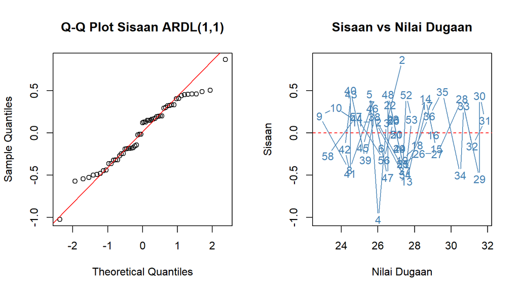

```r
par(mfrow = c(1, 2))
qqnorm(residuals(cons_lm3), main = "Q-Q Plot Sisaan ARDL(1,1)")
qqline(residuals(cons_lm3), col = "red")
plot(fitted(cons_lm3), residuals(cons_lm3), pch = 16, col = "steelblue",
     xlab = "Nilai Dugaan", ylab = "Sisaan", main = "Sisaan vs Nilai Dugaan")
abline(h = 0, col = "red", lty = 2)
```

```r
par(mfrow = c(1, 1))
```

# Perbandingan Model dan Pemilihan Model Terbaik

```r
akurasi <- matrix(c(mape.koyck, mape.dlm, mape.dlm2, mape.ardl, mape.ardl.op))
row.names(akurasi) <- c("Koyck",
                        "DLM q=2",
                        paste0("DLM q=", q.opt, " (optimum)"),
                        "ARDL (p=1, q=1)",
                        paste0("ARDL optimum (p=", p_opt, ", q=", q_opt, ")"))
colnames(akurasi) <- c("MAPE")
akurasi
```

```
##                                 MAPE
## Koyck                    0.029095435
## DLM q=2                  0.006409836
## DLM q=10 (optimum)       0.012725396
## ARDL (p=1, q=1)          0.007790350
## ARDL optimum (p=13, q=2) 0.014459118
```

```r
best <- row.names(akurasi)[which.min(akurasi[, 1])]
best
```

```
## [1] "DLM q=2"
```

Berdasarkan nilai **Mean Absolute Percentage Error (MAPE)**, model dengan nilai MAPE terkecil adalah **DLM q=2**, yaitu sebesar **0.00641** atau sekitar **0.64%**. Selanjutnya, ARDL (p=1, q=1) memiliki MAPE sebesar **0.78%**, DLM q=10 sebesar **1.27%**, ARDL optimum sebesar **1.45%**, dan Koyck sebesar **2.91%**.

Dengan demikian, **DLM q=2 dipilih sebagai model terbaik** karena menghasilkan nilai MAPE paling kecil, yang menunjukkan bahwa model tersebut memiliki tingkat kesalahan prediksi paling rendah dibandingkan model lainnya.

## Plot Perbandingan Hasil Peramalan

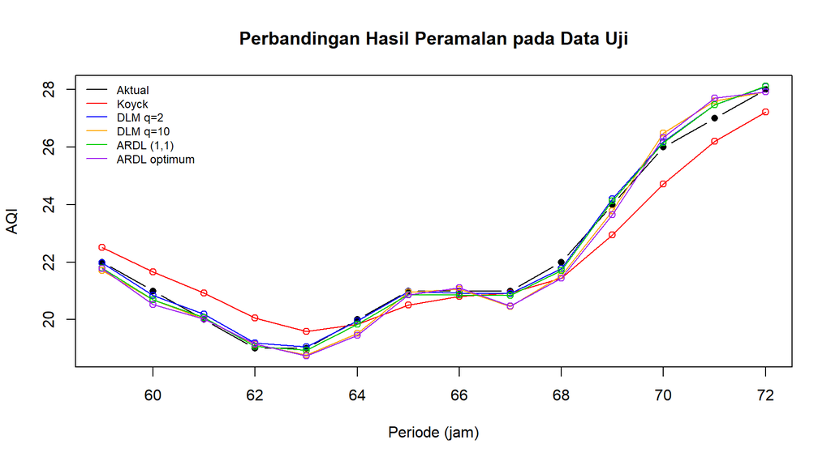

```r
rng <- range(c(test$Yt, fore.koyck$forecasts, fore.dlm$forecasts,
               fore.dlm2$forecasts, fore.ardl$forecasts,
               fore.ardl.op$forecasts))

plot(test$t, test$Yt, type = "b", pch = 16, col = "black", ylim = rng,
     xlab = "Periode (jam)", ylab = "AQI",
     main = "Perbandingan Hasil Peramalan pada Data Uji")
lines(test$t, fore.koyck$forecasts, col = "red");       points(test$t, fore.koyck$forecasts, col = "red", pch = 1)
lines(test$t, fore.dlm$forecasts, col = "blue");        points(test$t, fore.dlm$forecasts, col = "blue", pch = 1)
lines(test$t, fore.dlm2$forecasts, col = "orange");     points(test$t, fore.dlm2$forecasts, col = "orange", pch = 1)
lines(test$t, fore.ardl$forecasts, col = "green3");     points(test$t, fore.ardl$forecasts, col = "green3", pch = 1)
lines(test$t, fore.ardl.op$forecasts, col = "purple");  points(test$t, fore.ardl.op$forecasts, col = "purple", pch = 1)
legend("topleft",
       c("Aktual", "Koyck", "DLM q=2", paste0("DLM q=", q.opt),
         "ARDL (1,1)", "ARDL optimum"),
       lty = 1, col = c("black", "red", "blue", "orange", "green3", "purple"),
       cex = 0.75, bty = "n")
```

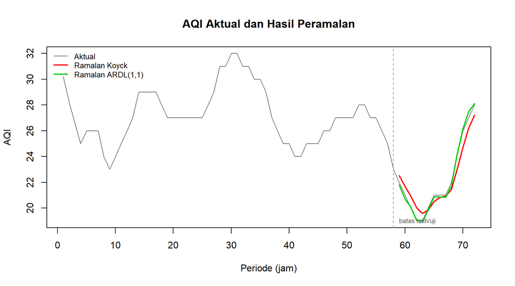

```r
# plot keseluruhan: data latih, data uji, dan ramalan model terbaik
plot(data$t, data$Yt, type = "l", col = "grey40",
     xlab = "Periode (jam)", ylab = "AQI",
     main = "AQI Aktual dan Hasil Peramalan")
abline(v = n_train, lty = 2, col = "grey60")
lines(test$t, fore.koyck$forecasts, col = "red", lwd = 2)
lines(test$t, fore.ardl$forecasts, col = "green3", lwd = 2)
legend("topleft", c("Aktual", "Ramalan Koyck", "Ramalan ARDL(1,1)"),
       lty = 1, lwd = c(1, 2, 2), col = c("grey40", "red", "green3"),
       cex = 0.8, bty = "n")
text(n_train, min(data$Yt), "batas latih/uji", pos = 4, cex = 0.7, col = "grey40")
```

# Kesimpulan

1. **Peubah penjelas.** Dari enam polutan yang tersedia, konsentrasi **ozon (`o3`)** memiliki korelasi paling kuat terhadap AQI Kota New Delhi dengan nilai korelasi sebesar $r \approx 0{,}9736$, sehingga dipilih sebagai peubah penjelas $X$.
2. **Model yang dicobakan.** Lima model regresi dengan peubah *lag* diterapkan pada data latih, yaitu **Koyck, DLM dengan** $q=2$, DLM dengan $q=10$ sebagai ordo optimum, ARDL$(1,1)$, serta ARDL dengan ordo optimum.
3. **Model terbaik.** Berdasarkan nilai **MAPE pada data uji**, model terbaik adalah **DLM dengan** $q=2$ dengan nilai MAPE sebesar **0,00641** atau sekitar **0,64%**. Nilai tersebut merupakan yang paling kecil dibandingkan Koyck sebesar 2,91%, DLM $q=10$ sebesar 1,27%, ARDL$(1,1)$ sebesar 0,78%, dan ARDL optimum sebesar 1,45%. Dengan demikian, DLM $q=2$ memberikan akurasi prediksi terbaik pada data uji.
4. **Uji asumsi.** Berdasarkan uji Durbin-Watson, Breusch-Pagan, dan Shapiro-Wilk pada model-model yang dibandingkan, **DLM** $q=2$ (Model 4) tidak menunjukkan adanya autokorelasi positif dan heteroskedastisitas karena masing-masing memiliki nilai-p sebesar **0,5554** dan **0,8149**. Namun, hasil uji Shapiro-Wilk menunjukkan nilai-p sebesar $7,243 \times 10^{-6}$, sehingga residual DLM $q=2$ belum memenuhi asumsi normalitas.
5. **Implikasi.** Hasil pemodelan menunjukkan bahwa konsentrasi ozon pada periode saat ini berperan penting dalam menjelaskan AQI. Meskipun beberapa model memasukkan pengaruh *lag*, model **DLM** $q=2$ memberikan akurasi prediksi terbaik. Oleh karena itu, pemantauan kualitas udara dapat mempertimbangkan informasi konsentrasi ozon pada periode berjalan maupun periode sebelumnya untuk meningkatkan prediksi AQI.